# MG205: Econometrics Theory and Applications

Empirical Exercise 5: Beauty

Jose Ignacio Gonzalez-Rojas

j.i.gonzalez-rojas@lse.ac.uk

London School of Economics and Political Science

## Today: Decomposing the Beauty Premium

### From Correlation to Mechanism

#### Roadmap

1. **Observational evidence:** The 15% beauty premium
2. Four competing channels
3. **Experimental design:** Mobius & Rosenblat (2006)

#### Goals

1. Test each channel separately
2. Quantify contributions

# Beauty Pays

## Attractive Workers Earn 10-15% More Than Average

### Hamermesh & Biddle (1994)

#### Stylized Facts

- Premium persists across occupations and industries
- Effect remains after controlling for education, experience, occupation
- Magnitude similar to gender wage gap

#### The Puzzle

If beauty doesn’t affect productivity, why would employers pay more?

Could you profit by hiring less attractive workers at lower wages?

## Below-Average Looks Cost 15% in Wages

### Equivalent to Losing 2.5 Years of Education

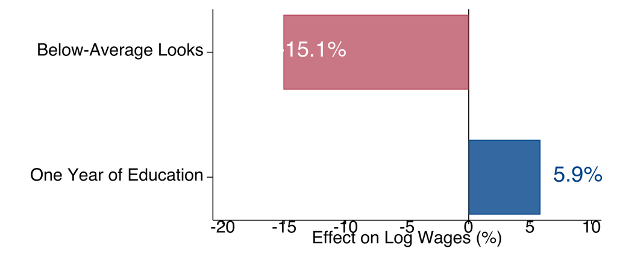

Being rated below-average costs as much as missing 2.5 years of education

## Four Channels Could Explain the Beauty Premium

### Only One Is Economically Efficient

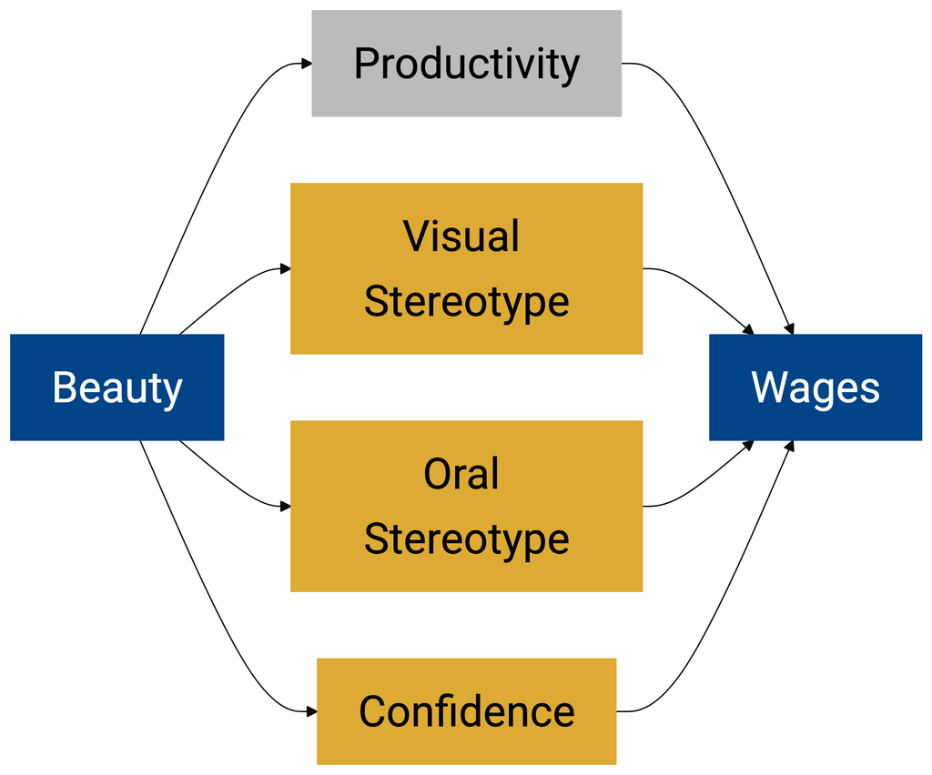

Gray = Productive (efficient) | Gold = Potentially discriminatory

# Channels Have Policy Implications

## The Wage Equation Separates Each Channel

### Interactions Identify Visual and Oral Effects

#### Wage Equation

$$\begin{aligned}
\log(\text{wage})_{ij} &= \beta_0 + \beta_1 \text{beauty}_j + \beta_2 (\text{beauty}_{j} \cdot \underbrace{\mathbb{1}[i \text{ sees } j\text{'s photo}]}_{\text{Visual}}) \\
&+ \beta_3 (\text{beauty}_j \cdot \underbrace{\mathbb{1}[i \text{ hears } j\text{'s voice}]}_{\text{Oral}}) + \gamma X_{ij} + \varepsilon_{ij}
\end{aligned}$$

#### Confidence Equation

$$\begin{aligned}
\log(\text{confidence})_j &= \alpha_0 + \alpha_1 \text{beauty}_j + \alpha_2 \log(\text{actual performance})_j \\
&+ \alpha_3 \log(\text{projected performance})_j + \delta X_j + \nu_j
\end{aligned}$$

If $\alpha_1 > 0$ after controls $\Rightarrow$ overconfidence

## Different Channels Require Different Policy Responses

### Efficiency vs. Discrimination

#### If Productivity Channel

- Premium is efficient
- Beautiful workers are actually more productive
- No intervention needed
- Hiring based on looks is rational

#### If Stereotype/Confidence Channels

- Premium reflects bias
- Beautiful workers are not more productive
- Blind hiring could help
- Employer training may be needed

We need an experiment to separate these channels

# An Experiment Can Separate Channels

## Mobius & Rosenblat (2006) Designed a Clever Experiment

### University of Tucumán, Argentina (2002-2003)

#### Sample

- 330 university students
- 33 sessions of 10 participants each
- 5 workers + 5 employers per session

#### Task

Solving computer mazes (15-minute work period)

- Practice round → projected performance
- Actual production → revealed ability

## Five Treatments Vary the Interaction Mode

### Each Employer Rates 5 Different Workers

| Treatment | Resume | Photo | Phone | Face-to-Face |
| --- | --- | --- | --- | --- |
| B (Baseline) | ✓ | — | — | — |
| V (Visual) | ✓ | ✓ | — | — |
| O (Oral) | ✓ | — | ✓ | — |
| VO (Both) | ✓ | ✓ | ✓ | — |
| FTF (Face-to-Face) | ✓ | ✓ | ✓ | ✓ |

Each employer rates 5 different workers → Employer fixed effects

## Randomization Ensures Exogeneity of Treatment

### What the Experiment Identifies

#### What Randomization Gives Us

- Treatment is **exogenous** by design
- $\text{Cov}(\text{treatment}, \varepsilon) = 0$
- No selection into treatment groups
- Causal interpretation of treatment effects

#### What It Does NOT Give Us

- Beauty is **not** randomly assigned
- Cannot claim causal effect of beauty on productivity
- But: Can test if beauty **predicts** productivity
- If no correlation → productivity channel ruled out

Randomization of treatment ≠ randomization of beauty

## Incentives Ensure Truthful Revelation

### Both Workers and Employers Are Paid for Accuracy

#### Worker Payment

$$\begin{aligned}
\text{Pay}_j &= 100 \times \text{Actual}_j \\
&- 40|\text{Estimate}_j - \text{Actual}_j| \\
&+ \sum_{i}\text{Wage}_{ij}
\end{aligned}$$

- Incentive for high performance
- Incentive for accurate self-assessment

#### Employer Payment

$$\text{Pay}_i = 4000 - \sum_{j=1}^{5} 40|\text{Wage}_{ij} - \text{Actual}_j|$$

- Incentive for accurate worker assessment
- Penalised for over/under-estimating ability

# Productivity Does Not Explain the Premium

## Beauty Has No Effect on Maze-Solving Ability

### Productivity Channel Ruled Out (Treatment B Only)

$$\widehat{\log(\text{actual})}_j = -\underset{(0.039)}{0.018} \cdot \text{beauty}_j - \underset{(0.012)}{0.039} \cdot \text{age}_j + \underset{(0.087)}{0.372} \cdot \mathbb{1}[j \text{ is male}] + X_{j}' \hat{\Gamma}$$

- Beauty coefficient is not statistically significant ($p > 0.10$)
- Males solve 37% more mazes ($p < 0.001$)

Beauty does not affect productivity

# Confidence Transmits Through Speech

## Beautiful Workers Report Higher Confidence

### +17% Confidence per SD of Beauty

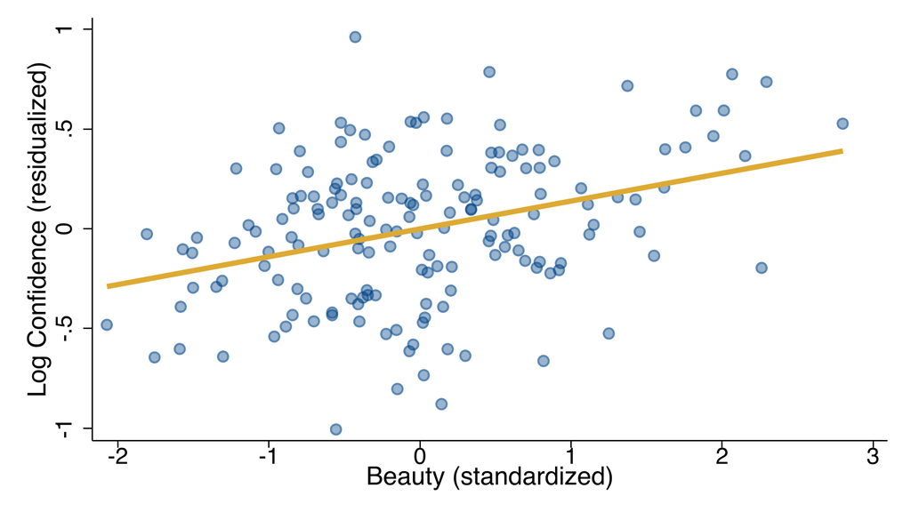

Residualized confidence (after controlling for actual and projected ability) vs. beauty. The positive slope indicates overconfidence.

+17% confidence per SD beauty, even after controlling for actual ability

## Beauty Causes Overconfidence

### Controlling for Both Actual AND Projected Ability

Beauty STILL predicts higher confidence. This is OVERCONFIDENCE

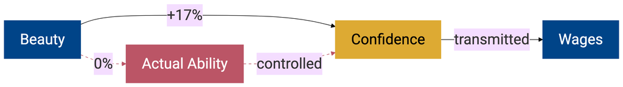

## Confidence Only Affects Wages When Employers Can Hear

### Oral Transmission Channel

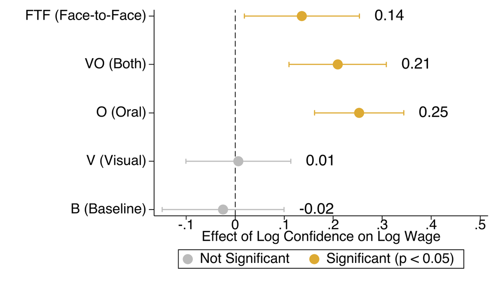

Effect of log confidence on log wage by treatment. Error bars show 95% CI. Confidence only matters in treatments with audio interaction.

Confidence is communicated through speech, not appearance

# Multiple Channels Contribute

## The Beauty Premium Emerges with Interaction

### From 0% to 12% Across Treatments

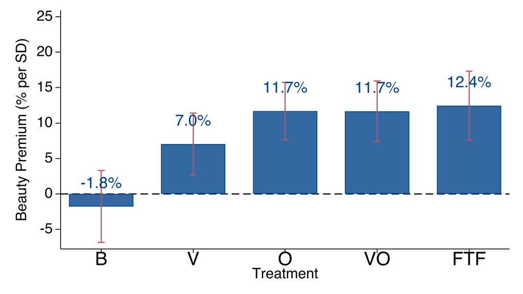

Effect of one SD increase in beauty on log wage by treatment. Error bars show 95% CI. No premium without interaction; premium emerges with visual OR oral contact.

No premium without interaction

## Channels Are Not Fully Additive

### The Full Model with Interactions

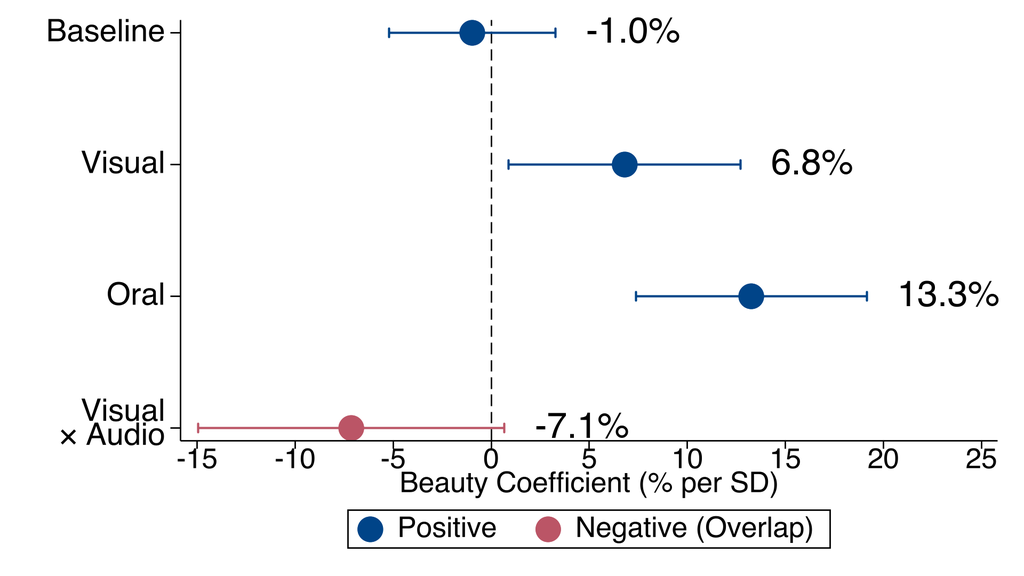

Decomposition coefficients from pooled regression. Visual and oral channels both contribute, but with negative interaction (channels overlap).

Face-to-face ≠ Visual + Oral (diminishing returns)

## Visual ~40%, Oral ~40%, Confidence ~20%

### Channels Have Diminishing Returns

The negative overlap term means channels have diminishing returns—face-to-face ≠ visual + oral

## Employers Do Not Sacrifice Accuracy for Beauty

### No Evidence of Taste-Based Discrimination

$$\begin{aligned}
\widehat{\log(\text{wage})}_{ij} &= \underset{(0.031)}{-0.010} \cdot \text{beauty}_j - \underset{(0.055)}{0.010} \cdot \mathbb{1}[i \text{ sets } j\text{'s wage}] \\
&- \underset{(0.057)}{0.058} \cdot (\text{beauty}_j \times \mathbb{1}[i \text{ sets } j\text{'s wage}]) + X_{ij}'\hat{\Gamma}
\end{aligned}$$

- Interaction coefficient: $-0.058$ with $p > 0.10$ (not significant)
- Employers do not inflate wages for beautiful workers when it “counts”

The premium reflects beliefs about productivity, not tastes for beauty

## Laboratory Results May Not Generalize Directly

### External Validity and Policy Implications

#### Limitations

- Student subjects (may not generalize to professional workers)
- Simple task (maze-solving vs. complex jobs)
- Short-term interaction (one session vs. repeated interactions)
- Laboratory setting (lower stakes than real hiring)

#### Policy Implications

1. Structured hiring with standardized questions
2. Phone screens before in-person interviews (removes visual bias)
3. Interviewer training on overconfidence detection

## Summary

### From Correlation to Mechanism

#### Findings

- **Observational evidence:** 15% beauty premium exists
- **Experiment:** Mobius & Rosenblat (2006) isolates channels
- **Productivity:** Ruled out (beauty ≠ ability)

#### Mechanism

- **Overconfidence:** Beauty causes excess confidence
- **Oral transmission:** Confidence only affects wages through speech
- **Decomposition:** Visual ~40%, Oral ~40%, Confidence ~20%

**Next Week:** Exploiting time variation—Panel data methods

# References

## References

Hamermesh, D. S., & Biddle, J. E. (1994). Beauty and the Labor Market. *American Economic Review*, *84*(5), 1174–1194.

Mobius, M. M., & Rosenblat, T. S. (2006). Why Beauty Matters. *American Economic Review*, *96*(1), 222–235. https://doi.org/10.1257/000282806776157515